# Netflix - Data Exploration and Visualisation

### Numerical Columns

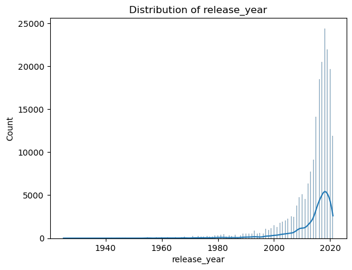

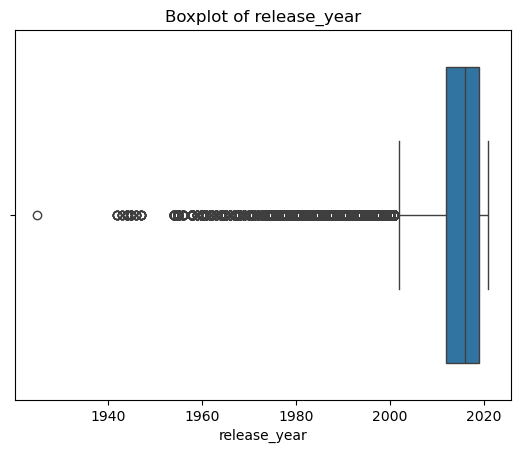

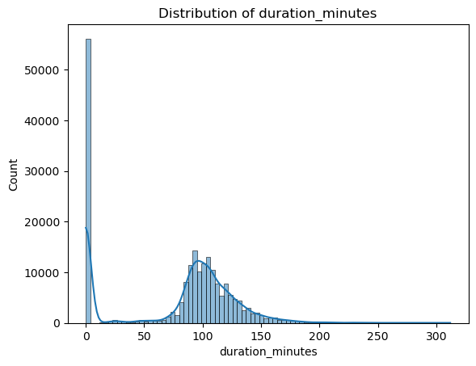

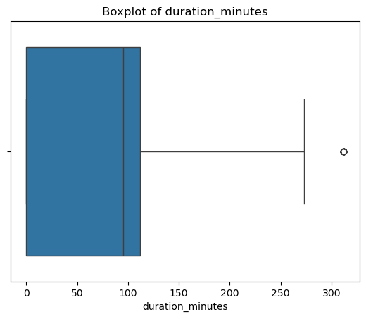

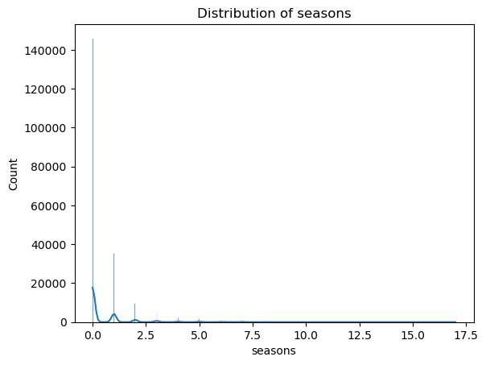

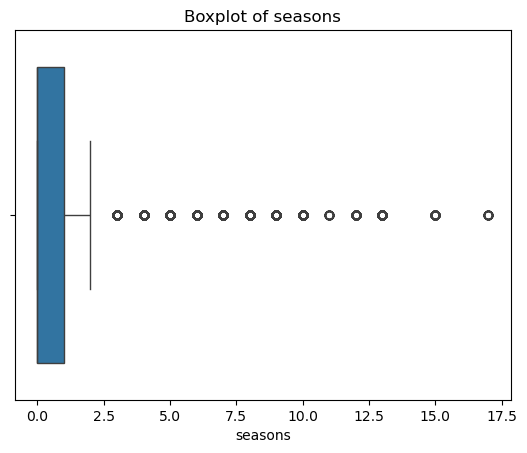

```python
num_cols = ['release_year', 'duration_minutes', 'seasons']

for col in num_cols:
    sns.histplot(df_final[col], kde=True)
    plt.title(f'Distribution of {col}')
    plt.show()

    sns.boxplot(x=df_final[col])
    plt.title(f'Boxplot of {col}')
    plt.show()
```

**Inferences**

- The number of releases has increased over the years, peaking in recent years.
- Most TV Shows have 1-2 seasons.

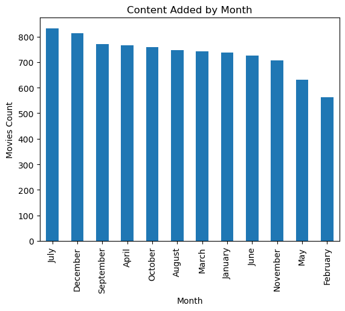

```python
# Visualizing the content added by month
df_final.groupby('month_added').agg({'title':'nunique'}).reset_index().sort_values(by='title', ascending=False).plot(kind='bar', x='month_added', y='title', legend=False)
plt.title('Content Added by Month')
plt.ylabel('Movies Count')
plt.xlabel('Month')
plt.show()
```

Most content is released in July and December to capitalize on peak audience engagement during holidays and seasonal breaks.

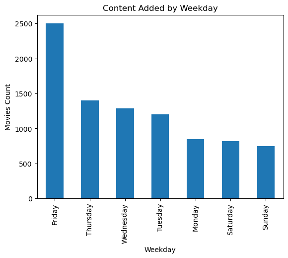

```python
# Visualizing the content added by weekday
df_final.groupby('weekday_added').agg({'title':'nunique'}).reset_index().sort_values(by='title', ascending=False).plot(kind='bar', x='weekday_added', y='title', legend=False)
plt.title('Content Added by Weekday')
plt.ylabel('Movies Count')
plt.xlabel('Weekday')
plt.show()
```

New content is primarily released on Fridays to capture weekend audiences.

```python
# top 10 countries producing movies
top_10_movie_country = (df_final[df_final['type'] == 'Movie']
                        .groupby(['Country'])
                        .agg({'title': 'nunique'})
                        .reset_index().sort_values(by='title', ascending=False)[:10])
top_10_movie_country.reset_index(drop=True, inplace=True)
top_10_movie_country
```

|  | Country | title |
| --- | --- | --- |
| 0 | United States | 2937 |
| 1 | India | 1040 |
| 2 | United Kingdom | 556 |
| 3 | Canada | 334 |
| 4 | France | 318 |
| 5 | Germany | 187 |
| 6 | Spain | 176 |
| 7 | Unknown Country | 156 |
| 8 | Japan | 138 |
| 9 | Nigeria | 129 |

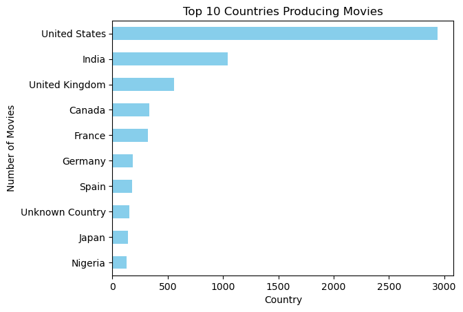

```python
# Visualizing the top 10 countries producing movies
top_10_movie_country.sort_values(by='title', ascending=True).plot(kind='barh', x='Country', y='title', legend=False, color='skyblue')
plt.title('Top 10 Countries Producing Movies')
plt.xlabel('Country')
plt.ylabel('Number of Movies')
plt.show()
```

United States, India and United Kingdom are the leading movie content creators.

```python
# top 10 countries producing TV Shows
top_10_tvshow_country = (df_final[df_final['type'] == 'TV Show']
                        .groupby(['Country'])
                        .agg({'title': 'nunique'})
                        .reset_index().sort_values(by='title', ascending=False)[:10])
top_10_tvshow_country.reset_index(drop=True, inplace=True)
top_10_tvshow_country
```

|  | Country | title |
| --- | --- | --- |
| 0 | United States | 1308 |
| 1 | United Kingdom | 273 |
| 2 | Japan | 200 |
| 3 | South Korea | 171 |
| 4 | Canada | 126 |
| 5 | France | 91 |
| 6 | India | 86 |
| 7 | Taiwan | 72 |
| 8 | Australia | 66 |
| 9 | Spain | 63 |

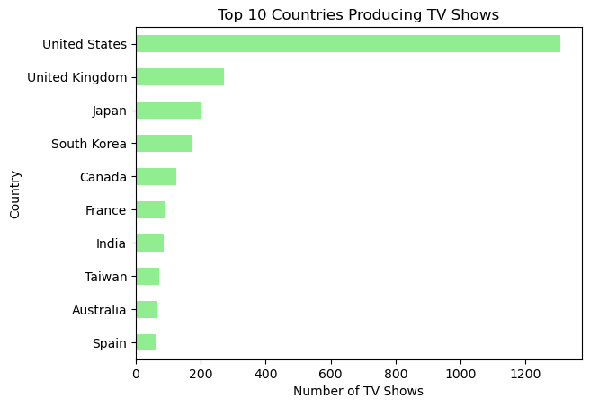

```python
# Visualizing the top 10 countries producing TV Shows
top_10_tvshow_country.sort_values(by='title', ascending=True).plot(kind='barh', x='Country', y='title', legend=False, color='lightgreen')
plt.title('Top 10 Countries Producing TV Shows')
plt.xlabel('Number of TV Shows')
plt.ylabel('Country')
plt.show()
```

United States, United Kingdom, Japan and South Korea are the leading TV Shows content creators.

```python
df_final.columns
```

```
Index(['title', 'Actors', 'Directors', 'Genre', 'Country', 'show_id', 'type',
       'date_added', 'release_year', 'rating', 'duration_minutes', 'seasons',
       'duration', 'month_added', 'year_added', 'weekday_added'],
      dtype='object')
```

```python
# Best week to release Movies
week_movie = df_final['date_added'].dt.isocalendar().week
best_week_movie = df_final[df_final['type'] == 'Movie'].groupby([week_movie, 'month_added']).agg({'title': 'nunique'}).reset_index().sort_values(by='title', ascending=False)[:10]
best_week_movie
```

|  | week | month_added | title |
| --- | --- | --- | --- |
| 1 | 1 | January | 227 |
| 59 | 44 | November | 210 |
| 54 | 40 | October | 194 |
| 11 | 9 | March | 161 |
| 41 | 31 | August | 161 |
| 35 | 27 | July | 150 |
| 47 | 35 | September | 148 |
| 24 | 18 | May | 142 |
| 33 | 26 | July | 125 |
| 20 | 16 | April | 124 |

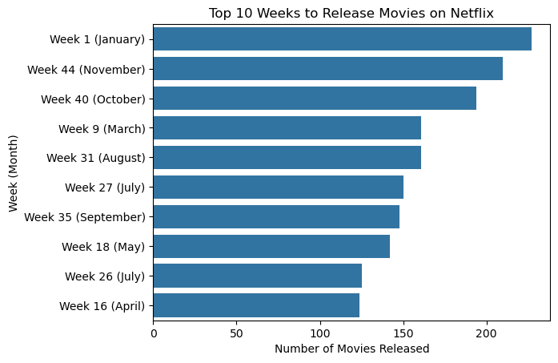

```python
# Top 10 Weeks to Release Movies on Netflix
best_week_movie['label'] = 'Week ' + best_week_movie['week'].astype(str) + ' (' + best_week_movie['month_added'] + ')'

best_week_movie = best_week_movie.sort_values(by='title', ascending=False)

sns.barplot(
    data=best_week_movie,
    x='title',
    y='label'
)
plt.title('Top 10 Weeks to Release Movies on Netflix')
plt.xlabel('Number of Movies Released')
plt.ylabel('Week (Month)')
plt.show()
```

The first week of January and weeks in November, October and March are the best for movie releases.

```python
# Best week to release TV Shows
week_tvshow = df_final['date_added'].dt.isocalendar().week
best_week_tvshow = df_final[df_final['type'] == 'TV Show'].groupby([week_tvshow, 'month_added']).agg({'title': 'nunique'}).reset_index().sort_values(by='title', ascending=False)[:10]
best_week_tvshow
```

|  | week | month_added | title |
| --- | --- | --- | --- |
| 35 | 27 | July | 84 |
| 31 | 24 | June | 75 |
| 41 | 31 | August | 71 |
| 66 | 50 | December | 70 |
| 49 | 37 | September | 69 |
| 53 | 40 | October | 67 |
| 5 | 5 | February | 59 |
| 58 | 44 | November | 57 |
| 47 | 35 | September | 53 |
| 19 | 15 | April | 53 |

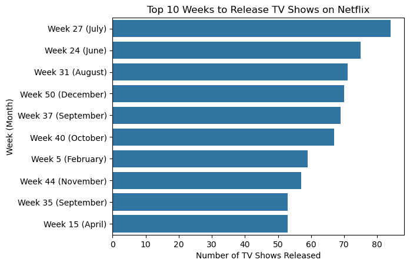

```python
# Top 10 Weeks to Release TV Shows on Netflix
best_week_tvshow['label'] = 'Week ' + best_week_tvshow['week'].astype(str) + ' (' + best_week_tvshow['month_added'] + ')'

best_week_tvshow = best_week_tvshow.sort_values(by='title', ascending=False)

sns.barplot(
    data=best_week_tvshow,
    x='title',
    y='label'
)
plt.title('Top 10 Weeks to Release TV Shows on Netflix')
plt.xlabel('Number of TV Shows Released')
plt.ylabel('Week (Month)')
plt.show()
```

TV shows are most frequently released in the weeks of July, June, and August.

```python
# Top 10 Actors with most appearances in movies
top_10_actors_movie = (df_final[df_final['type'] == 'Movie']
                       .groupby(['Actors'])
                       .agg({'title': 'nunique'})
                       .reset_index().sort_values(by='title', ascending=False)[1:10])
top_10_actors_movie.reset_index(drop=True, inplace=True)
top_10_actors_movie
```

|  | Actors | title |
| --- | --- | --- |
| 0 | Anupam Kher | 42 |
| 1 | Shah Rukh Khan | 35 |
| 2 | Naseeruddin Shah | 32 |
| 3 | Akshay Kumar | 30 |
| 4 | Om Puri | 30 |
| 5 | Amitabh Bachchan | 28 |
| 6 | Julie Tejwani | 28 |
| 7 | Paresh Rawal | 28 |
| 8 | Rupa Bhimani | 27 |